# FordGoBike System Data Exploratation

## Investigation Overview

In this project the features that effect the demand for bikes (i.e number of bike trips) and the duration of the trip are investigated. The main focus was on the weekday, user type, and whether bike was shared for all trip.

## Dataset Overview

In this project, the trip data of FordGoBike from 2018 to 2019 will be explored. The data is available on 'https://s3.amazonaws.com/baywheels-data/index.html'. After wrangling the final cleaned dataset has 4370704 trip data with 18 features.

## Distribution of Duration of trips

The distribution of duration of trips is right skewed with wide range of data. On log scale, the distribution is similar to normal distribution.The majority of trips have duration between 100-3000 seconds

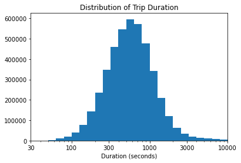

```python
#plotting on log scale
bins = 10 ** np.arange(0, np.log10(df_clean.duration_sec.max())+0.1, 0.1)
plt.hist(data=df_clean,x='duration_sec', bins = bins)
plt.xscale('log')
tick_locs = [30, 100, 300, 1000, 3000,10000]
plt.xticks(tick_locs, tick_locs)
plt.xlim(30,10000)
plt.xlabel('Duration (seconds)')
plt.title('Distribution of Trip Duration');
```

## Distribution of trips by day of week

The number of trip on all weekdays i.e Monday to Friday is almost same with a slightly lower values on Monday and Friday . The number of trips on weekends is considerably lower than on weekdays. This can mean that majority of trips are work type trips rather than leisure trips

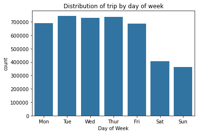

```python
sb.countplot(data = df_clean, x = 'weekday', color = sb.color_palette()[0])
plt.xticks((0,1,2,3,4,5,6),('Mon','Tue','Wed','Thur','Fri','Sat','Sun'))
plt.title('Distribution of trip by day of week')
plt.xlabel('Day of Week');
```

## Distribution of trips by User Type

The number of trip made by subscribers is far greater than customers. This makes intutive sense as people who do take subscription have greater demand for the bikes. This also is in accordance to the previous observation that higher number of trips occur on weekday.

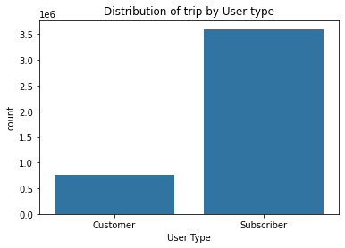

```python
sb.countplot(data = df_clean, x = 'user_type', color = sb.color_palette()[0])
plt.title('Distribution of trip by User type')
plt.xlabel('User Type');
```

## Interaction between weekday, user type and duration

The mean duration of customer user type is higher than subscriber on each day of week.Moreover although the mean duration of subscribers remains almost constant, that for customers increases on weekend. This shows that customers tend to use bikes for longer trips while subscribers don't hesistate to use bike share for short trips too. It can also be said that customers tend to take longer leisure (weekends) trips than subscribers

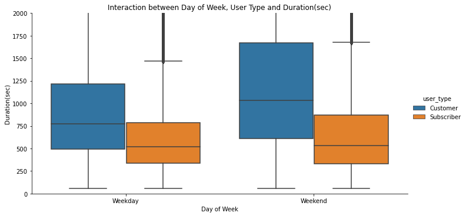

```python
sb.catplot(x="weekend", y="duration_sec", hue="user_type",
               data=df_clean, kind="box",height=5, aspect=2)
plt.ylim((0,2000))
plt.title('Interaction between Day of Week, User Type and Duration(sec)')
plt.xlabel('Day of Week')
plt.ylabel('Duration(sec)');
```

## Interaction between weekday, bike_share_for_all_trip and duration

Trips without bike share for entire trip had greater duration than trips without bike share for entire trip on both weekdays and weekends. However the difference is more pronounced on weekends than on weekdays. This shows that longer duration on other modes during a trip is more likely in case of a leisure trip (trips on weekend) than work trips (trips on weekdays).

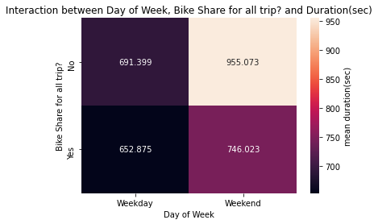

```python
cat_means = df_clean.groupby(['weekend', 'bike_share_for_all_trip']).mean()['duration_sec'].reset_index()
cat_means = cat_means.pivot(index = 'bike_share_for_all_trip',
                            columns = 'weekend',values = 'duration_sec')
sb.heatmap(cat_means, annot = True, fmt = '.3f',
           cbar_kws = {'label' : 'mean duration(sec)'})
plt.title('Interaction between Day of Week, Bike Share for all trip? and Duration(sec)')
plt.xlabel('Day of Week')
plt.ylabel('Bike Share for all trip?');
```